# house_price_pre_3

Ravi Hela

22/03/2020

## Load libraries

```r
library(tidymodels)
library(readr)
library(tidyverse)
library(lubridate)
library(skimr)
library(DataExplorer)
library(tidyquant)
library(corrr)
library(caret)
library(vip)
library(Hmisc)
```

## Define some useful functions

Caliing few function to help get correlation dataframe

```r
#function to help filter corelated variables
source("correlation_df.R")
#get model metrics in a dataframe
source("model_metric_compare.R")
```

## Read data

```r
train <- read_csv("train.csv")
test <- read_csv("test.csv")

names(train) <- make.names(names(train))
names(test) <- make.names(names(test))
```

The “test” file is the one to be used for Kaggle submission. This will not beused for model training but is a good for EDA use. For trainiing model we crate a validation set from train file later on. For model training we call the validation set as testing set

## Combinie test and train for EDA

```r
lapply(list(train = train, test = test), skim)
```

```
## $train
## -- Data Summary ------------------------
##                            Values
## Name                       X[[i]]
## Number of rows             1460
## Number of columns          81
## _______________________
## Column type frequency:
##   character                43
##   numeric                  38
## ________________________
## Group variables            None
##
## -- Variable type: character ----------------------------------------------------
## # A tibble: 43 x 8
```

[output cut: 270 more lines]

```r
test$SalePrice <- NA
test$set <- "test"
train$set <- "train"
house_comb <- bind_rows(train, test)
```

Lets look at the summary of this combined dataset

Data summary

| Name | house_comb |
| --- | --- |
| Number of rows | 2919 |
| Number of columns | 82 |
| _______________________ |  |
| Column type frequency: |  |
| character | 44 |
| numeric | 38 |
| ________________________ |  |
| Group variables | None |

**Variable type: character**

| skim_variable | n_missing | complete_rate | min | max | empty | n_unique | whitespace |
| --- | --- | --- | --- | --- | --- | --- | --- |
| MSZoning | 4 | 1.00 | 2 | 7 | 0 | 5 | 0 |
| Street | 0 | 1.00 | 4 | 4 | 0 | 2 | 0 |
| Alley | 2721 | 0.07 | 4 | 4 | 0 | 2 | 0 |
| LotShape | 0 | 1.00 | 3 | 3 | 0 | 4 | 0 |
| LandContour | 0 | 1.00 | 3 | 3 | 0 | 4 | 0 |
| Utilities | 2 | 1.00 | 6 | 6 | 0 | 2 | 0 |
| LotConfig | 0 | 1.00 | 3 | 7 | 0 | 5 | 0 |
| LandSlope | 0 | 1.00 | 3 | 3 | 0 | 3 | 0 |
| Neighborhood | 0 | 1.00 | 5 | 7 | 0 | 25 | 0 |
| Condition1 | 0 | 1.00 | 4 | 6 | 0 | 9 | 0 |
| Condition2 | 0 | 1.00 | 4 | 6 | 0 | 8 | 0 |
| BldgType | 0 | 1.00 | 4 | 6 | 0 | 5 | 0 |
| HouseStyle | 0 | 1.00 | 4 | 6 | 0 | 8 | 0 |
| RoofStyle | 0 | 1.00 | 3 | 7 | 0 | 6 | 0 |
| RoofMatl | 0 | 1.00 | 4 | 7 | 0 | 8 | 0 |
| Exterior1st | 1 | 1.00 | 5 | 7 | 0 | 15 | 0 |
| Exterior2nd | 1 | 1.00 | 5 | 7 | 0 | 16 | 0 |
| MasVnrType | 24 | 0.99 | 4 | 7 | 0 | 4 | 0 |
| ExterQual | 0 | 1.00 | 2 | 2 | 0 | 4 | 0 |
| ExterCond | 0 | 1.00 | 2 | 2 | 0 | 5 | 0 |
| Foundation | 0 | 1.00 | 4 | 6 | 0 | 6 | 0 |
| BsmtQual | 81 | 0.97 | 2 | 2 | 0 | 4 | 0 |
| BsmtCond | 82 | 0.97 | 2 | 2 | 0 | 4 | 0 |
| BsmtExposure | 82 | 0.97 | 2 | 2 | 0 | 4 | 0 |
| BsmtFinType1 | 79 | 0.97 | 3 | 3 | 0 | 6 | 0 |
| BsmtFinType2 | 80 | 0.97 | 3 | 3 | 0 | 6 | 0 |
| Heating | 0 | 1.00 | 4 | 5 | 0 | 6 | 0 |
| HeatingQC | 0 | 1.00 | 2 | 2 | 0 | 5 | 0 |
| CentralAir | 0 | 1.00 | 1 | 1 | 0 | 2 | 0 |
| Electrical | 1 | 1.00 | 3 | 5 | 0 | 5 | 0 |
| KitchenQual | 1 | 1.00 | 2 | 2 | 0 | 4 | 0 |
| Functional | 2 | 1.00 | 3 | 4 | 0 | 7 | 0 |
| FireplaceQu | 1420 | 0.51 | 2 | 2 | 0 | 5 | 0 |
| GarageType | 157 | 0.95 | 6 | 7 | 0 | 6 | 0 |
| GarageFinish | 159 | 0.95 | 3 | 3 | 0 | 3 | 0 |
| GarageQual | 159 | 0.95 | 2 | 2 | 0 | 5 | 0 |
| GarageCond | 159 | 0.95 | 2 | 2 | 0 | 5 | 0 |
| PavedDrive | 0 | 1.00 | 1 | 1 | 0 | 3 | 0 |
| PoolQC | 2909 | 0.00 | 2 | 2 | 0 | 3 | 0 |
| Fence | 2348 | 0.20 | 4 | 5 | 0 | 4 | 0 |
| MiscFeature | 2814 | 0.04 | 4 | 4 | 0 | 4 | 0 |
| SaleType | 1 | 1.00 | 2 | 5 | 0 | 9 | 0 |
| SaleCondition | 0 | 1.00 | 6 | 7 | 0 | 6 | 0 |
| set | 0 | 1.00 | 4 | 5 | 0 | 2 | 0 |

**Variable type: numeric**

| skim_variable | n_missing | complete_rate | mean | sd | p0 | p25 | p50 | p75 | p100 | hist |
| --- | --- | --- | --- | --- | --- | --- | --- | --- | --- | --- |
| Id | 0 | 1.00 | 1460.00 | 842.79 | 1 | 730.5 | 1460.0 | 2189.5 | 2919 | ▇▇▇▇▇ |
| MSSubClass | 0 | 1.00 | 57.14 | 42.52 | 20 | 20.0 | 50.0 | 70.0 | 190 | ▇▅▂▁▁ |
| LotFrontage | 486 | 0.83 | 69.31 | 23.34 | 21 | 59.0 | 68.0 | 80.0 | 313 | ▇▃▁▁▁ |
| LotArea | 0 | 1.00 | 10168.11 | 7887.00 | 1300 | 7478.0 | 9453.0 | 11570.0 | 215245 | ▇▁▁▁▁ |
| OverallQual | 0 | 1.00 | 6.09 | 1.41 | 1 | 5.0 | 6.0 | 7.0 | 10 | ▁▂▇▅▁ |
| OverallCond | 0 | 1.00 | 5.56 | 1.11 | 1 | 5.0 | 5.0 | 6.0 | 9 | ▁▁▇▅▁ |
| YearBuilt | 0 | 1.00 | 1971.31 | 30.29 | 1872 | 1953.5 | 1973.0 | 2001.0 | 2010 | ▁▂▃▆▇ |
| YearRemodAdd | 0 | 1.00 | 1984.26 | 20.89 | 1950 | 1965.0 | 1993.0 | 2004.0 | 2010 | ▅▂▂▃▇ |
| MasVnrArea | 23 | 0.99 | 102.20 | 179.33 | 0 | 0.0 | 0.0 | 164.0 | 1600 | ▇▁▁▁▁ |
| BsmtFinSF1 | 1 | 1.00 | 441.42 | 455.61 | 0 | 0.0 | 368.5 | 733.0 | 5644 | ▇▁▁▁▁ |
| BsmtFinSF2 | 1 | 1.00 | 49.58 | 169.21 | 0 | 0.0 | 0.0 | 0.0 | 1526 | ▇▁▁▁▁ |
| BsmtUnfSF | 1 | 1.00 | 560.77 | 439.54 | 0 | 220.0 | 467.0 | 805.5 | 2336 | ▇▅▂▁▁ |
| TotalBsmtSF | 1 | 1.00 | 1051.78 | 440.77 | 0 | 793.0 | 989.5 | 1302.0 | 6110 | ▇▃▁▁▁ |
| X1stFlrSF | 0 | 1.00 | 1159.58 | 392.36 | 334 | 876.0 | 1082.0 | 1387.5 | 5095 | ▇▃▁▁▁ |
| X2ndFlrSF | 0 | 1.00 | 336.48 | 428.70 | 0 | 0.0 | 0.0 | 704.0 | 2065 | ▇▃▂▁▁ |
| LowQualFinSF | 0 | 1.00 | 4.69 | 46.40 | 0 | 0.0 | 0.0 | 0.0 | 1064 | ▇▁▁▁▁ |
| GrLivArea | 0 | 1.00 | 1500.76 | 506.05 | 334 | 1126.0 | 1444.0 | 1743.5 | 5642 | ▇▇▁▁▁ |
| BsmtFullBath | 2 | 1.00 | 0.43 | 0.52 | 0 | 0.0 | 0.0 | 1.0 | 3 | ▇▆▁▁▁ |
| BsmtHalfBath | 2 | 1.00 | 0.06 | 0.25 | 0 | 0.0 | 0.0 | 0.0 | 2 | ▇▁▁▁▁ |
| FullBath | 0 | 1.00 | 1.57 | 0.55 | 0 | 1.0 | 2.0 | 2.0 | 4 | ▁▇▇▁▁ |
| HalfBath | 0 | 1.00 | 0.38 | 0.50 | 0 | 0.0 | 0.0 | 1.0 | 2 | ▇▁▅▁▁ |
| BedroomAbvGr | 0 | 1.00 | 2.86 | 0.82 | 0 | 2.0 | 3.0 | 3.0 | 8 | ▁▇▂▁▁ |
| KitchenAbvGr | 0 | 1.00 | 1.04 | 0.21 | 0 | 1.0 | 1.0 | 1.0 | 3 | ▁▇▁▁▁ |
| TotRmsAbvGrd | 0 | 1.00 | 6.45 | 1.57 | 2 | 5.0 | 6.0 | 7.0 | 15 | ▁▇▂▁▁ |
| Fireplaces | 0 | 1.00 | 0.60 | 0.65 | 0 | 0.0 | 1.0 | 1.0 | 4 | ▇▇▁▁▁ |
| GarageYrBlt | 159 | 0.95 | 1978.11 | 25.57 | 1895 | 1960.0 | 1979.0 | 2002.0 | 2207 | ▂▇▁▁▁ |
| GarageCars | 1 | 1.00 | 1.77 | 0.76 | 0 | 1.0 | 2.0 | 2.0 | 5 | ▅▇▂▁▁ |
| GarageArea | 1 | 1.00 | 472.87 | 215.39 | 0 | 320.0 | 480.0 | 576.0 | 1488 | ▃▇▃▁▁ |
| WoodDeckSF | 0 | 1.00 | 93.71 | 126.53 | 0 | 0.0 | 0.0 | 168.0 | 1424 | ▇▁▁▁▁ |
| OpenPorchSF | 0 | 1.00 | 47.49 | 67.58 | 0 | 0.0 | 26.0 | 70.0 | 742 | ▇▁▁▁▁ |
| EnclosedPorch | 0 | 1.00 | 23.10 | 64.24 | 0 | 0.0 | 0.0 | 0.0 | 1012 | ▇▁▁▁▁ |
| X3SsnPorch | 0 | 1.00 | 2.60 | 25.19 | 0 | 0.0 | 0.0 | 0.0 | 508 | ▇▁▁▁▁ |
| ScreenPorch | 0 | 1.00 | 16.06 | 56.18 | 0 | 0.0 | 0.0 | 0.0 | 576 | ▇▁▁▁▁ |
| PoolArea | 0 | 1.00 | 2.25 | 35.66 | 0 | 0.0 | 0.0 | 0.0 | 800 | ▇▁▁▁▁ |
| MiscVal | 0 | 1.00 | 50.83 | 567.40 | 0 | 0.0 | 0.0 | 0.0 | 17000 | ▇▁▁▁▁ |
| MoSold | 0 | 1.00 | 6.21 | 2.71 | 1 | 4.0 | 6.0 | 8.0 | 12 | ▅▆▇▃▃ |
| YrSold | 0 | 1.00 | 2007.79 | 1.31 | 2006 | 2007.0 | 2008.0 | 2009.0 | 2010 | ▇▇▇▇▃ |
| SalePrice | 1459 | 0.50 | 180921.20 | 79442.50 | 34900 | 129975.0 | 163000.0 | 214000.0 | 755000 | ▇▅▁▁▁ |

## EDA

### Lets do EDA for data quality.

We first check for missing values.

```
## # A tibble: 82 x 3
##    feature      num_missing pct_missing
##    <fct>              <int>       <dbl>
##  1 PoolQC              2909      0.997
##  2 MiscFeature         2814      0.964
##  3 Alley               2721      0.932
##  4 Fence               2348      0.804
##  5 SalePrice           1459      0.500
##  6 FireplaceQu         1420      0.486
##  7 LotFrontage          486      0.166
##  8 GarageYrBlt          159      0.0545
##  9 GarageFinish         159      0.0545
## 10 GarageQual           159      0.0545
## # ... with 72 more rows
```

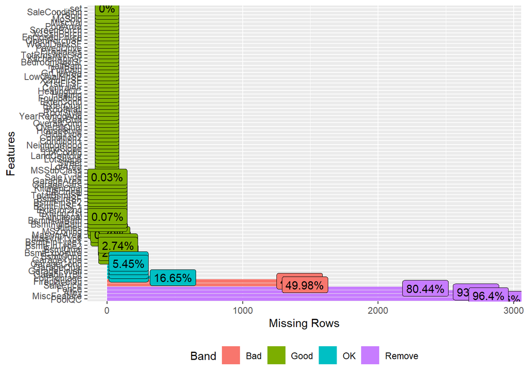

Most of the higher missing values is result of absence of a particular feature in the property as per Data description. We will code the missing values with appropriate categorical variable later on. Rest of the features have very low missing percentages which can be handled during model data preprocessing using median or knnimpte.

#### Further Data Exploration

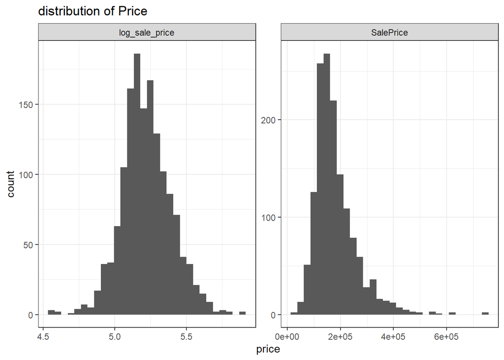

Sale Price distribtion is right skewed however log transformation is Normal and is a candidate for Linear Regression. Lets explore other features.

#### Check distribution of categorical variables

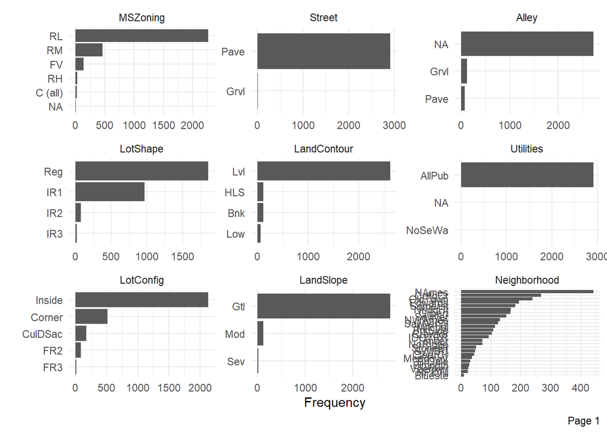

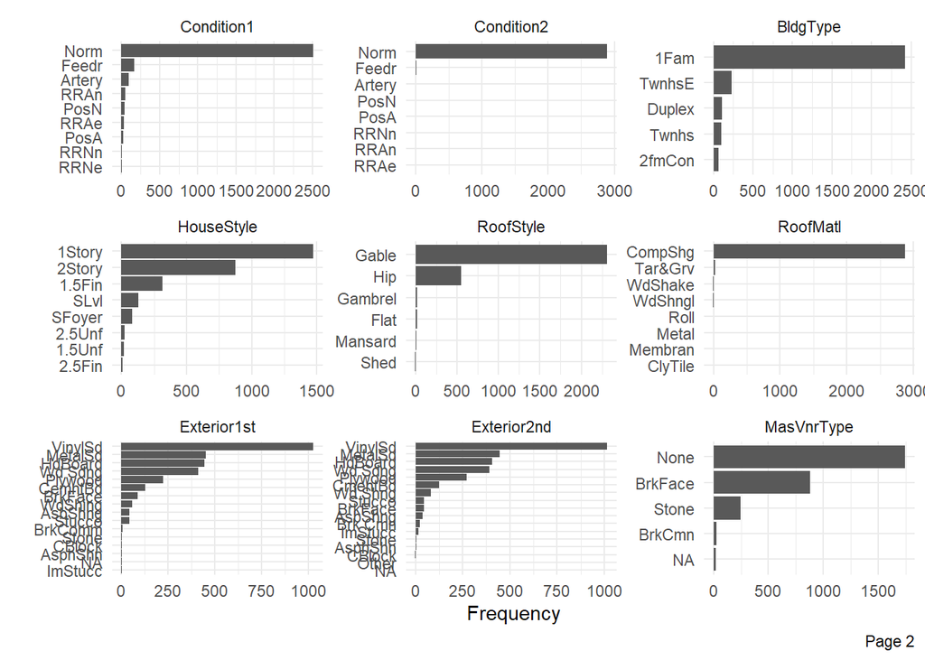

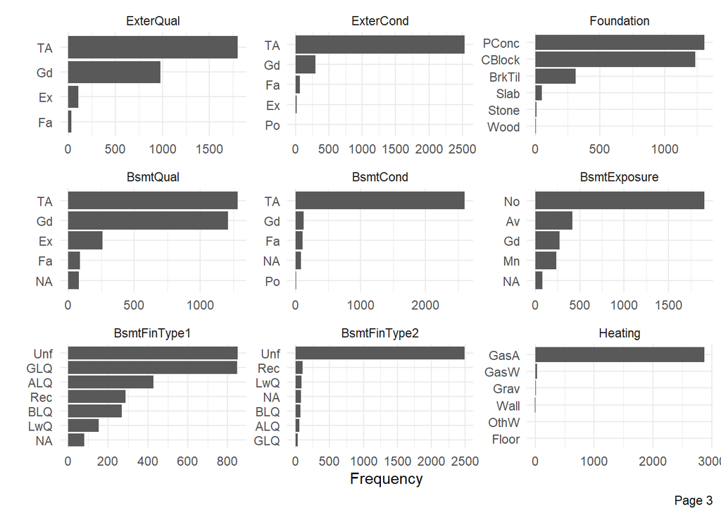

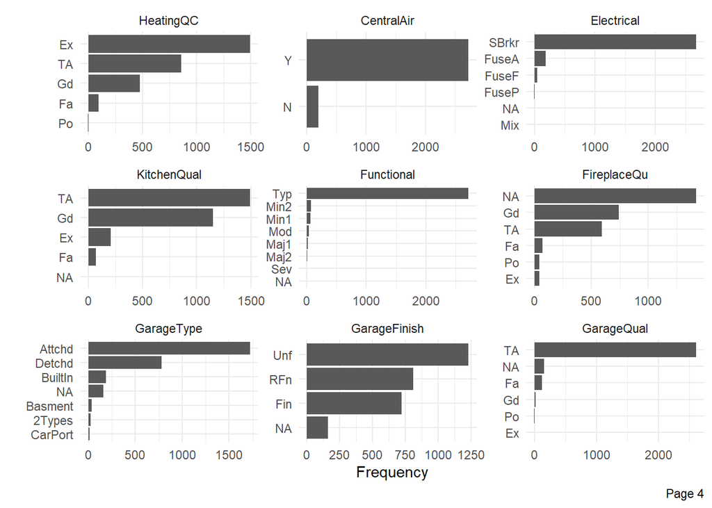

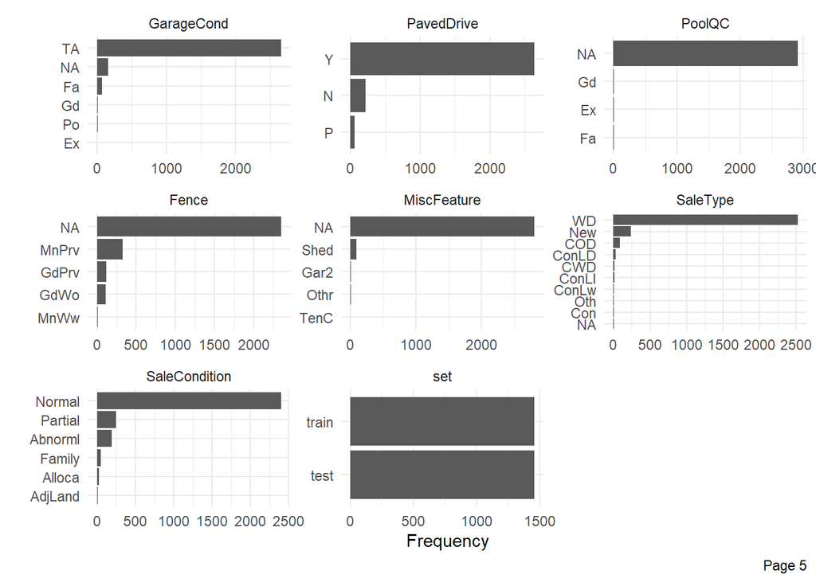

#### Check distribution of Numeric features

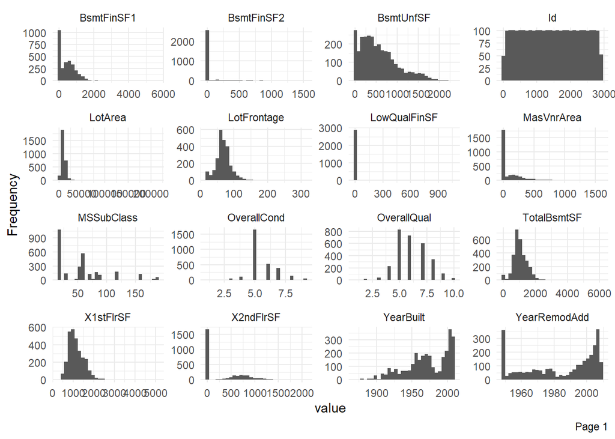

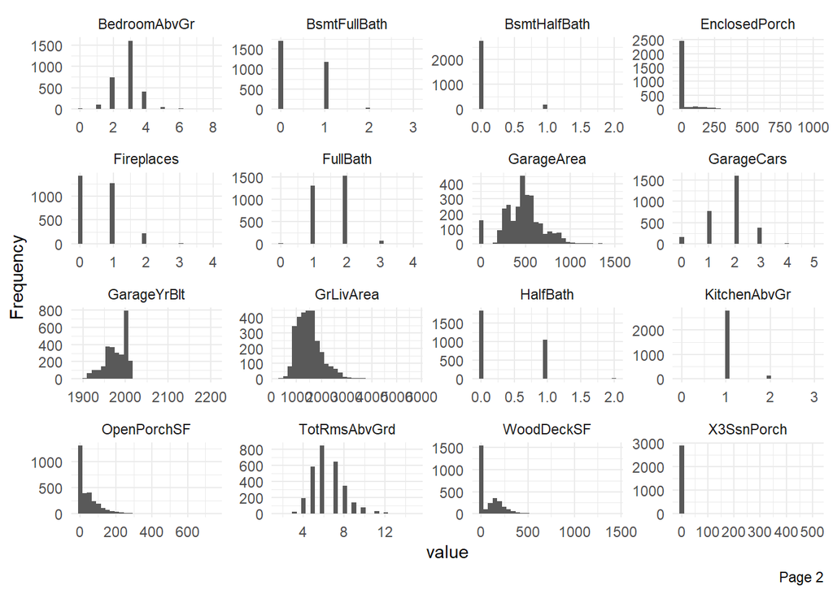

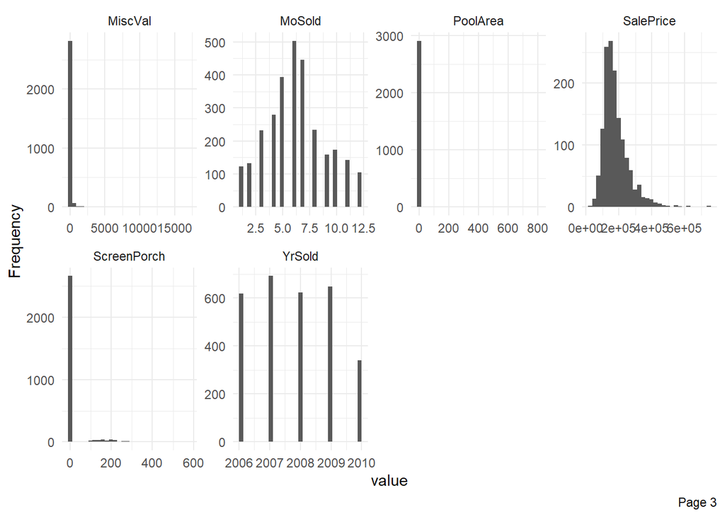

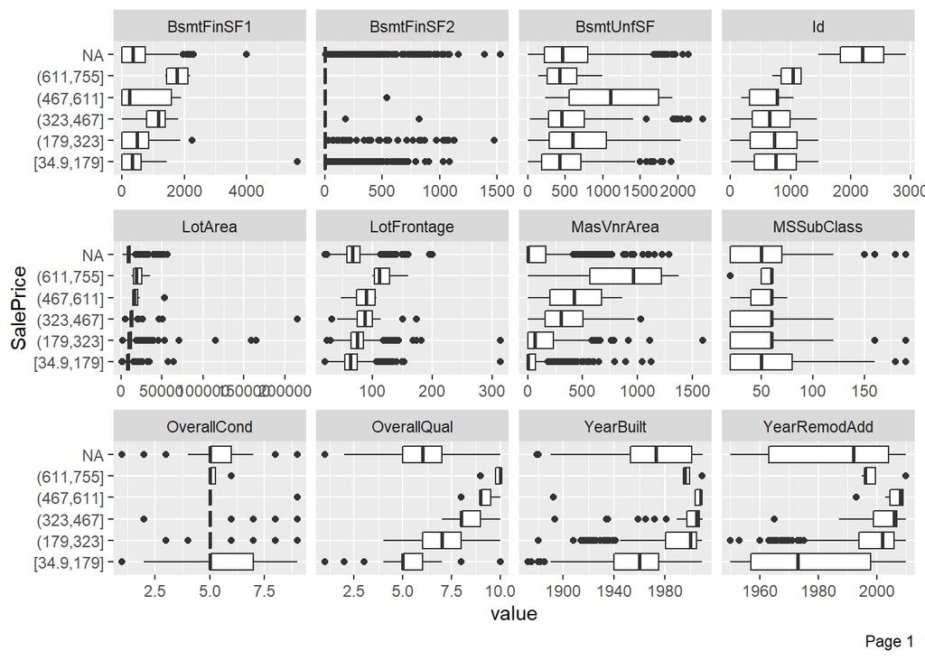

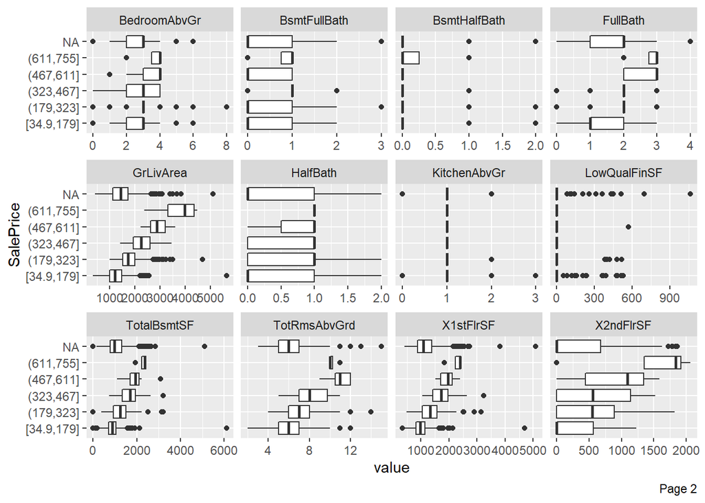

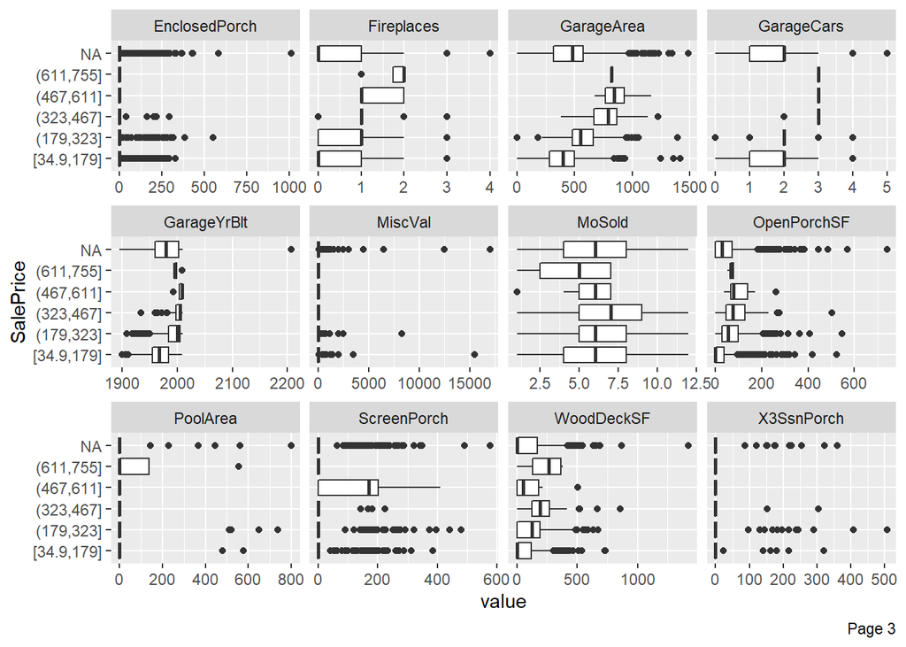

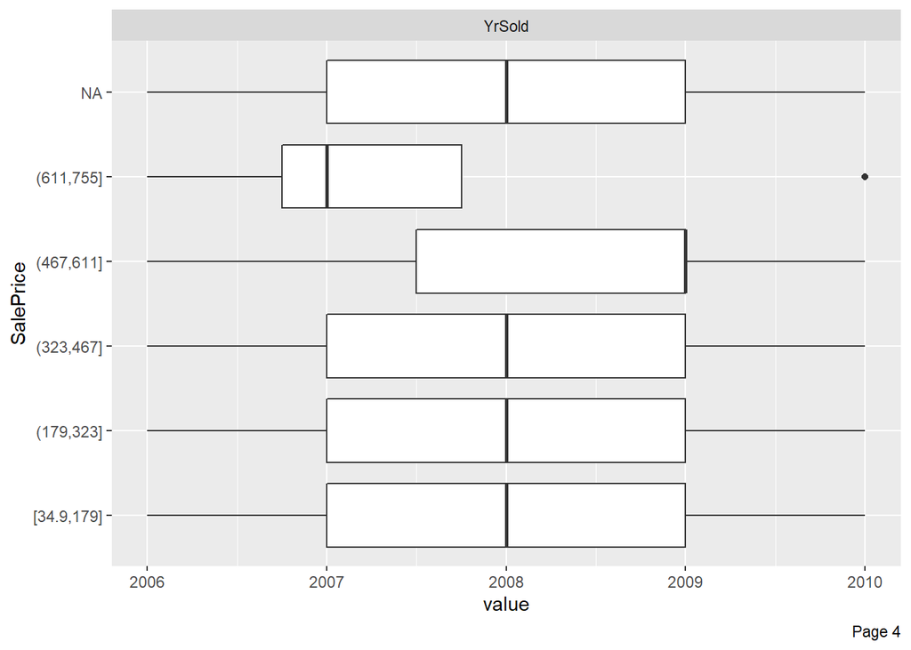

#### Checking correlation among variables

```
##
## Correlation method: 'pearson'
## Missing treated using: 'pairwise.complete.obs'
```

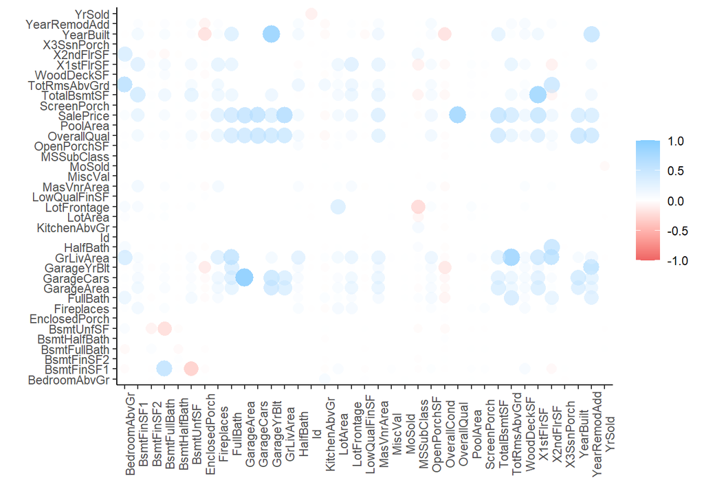

```
##
## Correlation method: 'pearson'
## Missing treated using: 'pairwise.complete.obs'
```

```
## # A tibble: 18 x 3
##    rowname      features      corr
##    <chr>        <chr>        <dbl>
##  1 GarageCars   GarageArea   0.890
##  2 YearBuilt    GarageYrBlt  0.835
##  3 GrLivArea    TotRmsAbvGrd 0.808
##  4 TotalBsmtSF  X1stFlrSF    0.802
##  5 OverallQual  SalePrice    0.791
##  6 GrLivArea    SalePrice    0.709
##  7 BedroomAbvGr TotRmsAbvGrd 0.670
##  8 X2ndFlrSF    GrLivArea    0.655
##  9 YearRemodAdd GarageYrBlt  0.652
## 10 GarageCars   SalePrice    0.640
## 11 BsmtFinSF1   BsmtFullBath 0.639
## 12 GrLivArea    FullBath     0.630
## 13 GarageArea   SalePrice    0.623
## 14 TotalBsmtSF  SalePrice    0.614
## 15 YearBuilt    YearRemodAdd 0.612
## 16 X2ndFlrSF    HalfBath     0.611
## 17 X1stFlrSF    SalePrice    0.606
## 18 OverallQual  GarageCars   0.601
```

#### Check for near zero variables

```
##   Street     LandContour  Utilities    LandSlope    Condition2      RoofMatl
##  Grvl:  12   Bnk: 117    AllPub:2916   Gtl:2778   Norm   :2889   CompShg:2876
##  Pave:2907   HLS: 120    NoSeWa:   1   Mod: 125   Feedr  :  13   Tar&Grv:  23
##              Low:  60    NA's  :   2   Sev:  16   Artery :   5   WdShake:   9
##              Lvl:2622                             PosA   :   4   WdShngl:   7
##                                                   PosN   :   4   ClyTile:   1
##                                                   RRNn   :   2   Membran:   1
##                                                   (Other):   2   (Other):   2
##  BsmtCond    BsmtFinType2   BsmtFinSF2       Heating      LowQualFinSF
##  Fa  : 104   ALQ :  52    Min.   :   0.00   Floor:   1   Min.   :   0.000
##  Gd  : 122   BLQ :  68    1st Qu.:   0.00   GasA :2874   1st Qu.:   0.000
##  Po  :   5   GLQ :  34    Median :   0.00   GasW :  27   Median :   0.000
##  TA  :2606   LwQ :  87    Mean   :  49.58   Grav :   9   Mean   :   4.694
##  NA's:  82   Rec : 105    3rd Qu.:   0.00   OthW :   2   3rd Qu.:   0.000
##              Unf :2493    Max.   :1526.00   Wall :   6   Max.   :1064.000
##              NA's:  80    NA's   :1
##   KitchenAbvGr     Functional   GarageQual  GarageCond   OpenPorchSF
##  Min.   :0.000   Typ    :2717   Ex  :   3   Ex  :   3   Min.   :  0.00
##  1st Qu.:1.000   Min2   :  70   Fa  : 124   Fa  :  74   1st Qu.:  0.00
##  Median :1.000   Min1   :  65   Gd  :  24   Gd  :  15   Median : 26.00
##  Mean   :1.045   Mod    :  35   Po  :   5   Po  :  14   Mean   : 47.49
##  3rd Qu.:1.000   Maj1   :  19   TA  :2604   TA  :2654   3rd Qu.: 70.00
##  Max.   :3.000   (Other):  11   NA's: 159   NA's: 159   Max.   :742.00
##                  NA's   :   2
##  EnclosedPorch      X3SsnPorch       ScreenPorch        PoolArea
##  Min.   :   0.0   Min.   :  0.000   Min.   :  0.00   Min.   :  0.000
##  1st Qu.:   0.0   1st Qu.:  0.000   1st Qu.:  0.00   1st Qu.:  0.000
##  Median :   0.0   Median :  0.000   Median :  0.00   Median :  0.000
##  Mean   :  23.1   Mean   :  2.602   Mean   : 16.06   Mean   :  2.252
##  3rd Qu.:   0.0   3rd Qu.:  0.000   3rd Qu.:  0.00   3rd Qu.:  0.000
##  Max.   :1012.0   Max.   :508.000   Max.   :576.00   Max.   :800.000
##
##     MiscVal
##  Min.   :    0.00
##  1st Qu.:    0.00
##  Median :    0.00
##  Mean   :   50.83
##  3rd Qu.:    0.00
##  Max.   :17000.00
##
```

### Curious to know if street type makes a difference

```
## # A tibble: 6 x 4
##   Var1  Var2       Grvl    Pave
##   <fct> <fct>     <dbl>   <dbl>
## 1 A     Min.     55993   34900
## 2 A     1st Qu.  88250  130000
## 3 A     Median  114250  163000
## 4 A     Mean    130190. 181131.
## 5 A     3rd Qu. 169650  214000
## 6 A     Max.    228950  755000
```

In general we do see House in pavement have higher Sale price than the Gravel.

### Checking affect of time over Sale Price

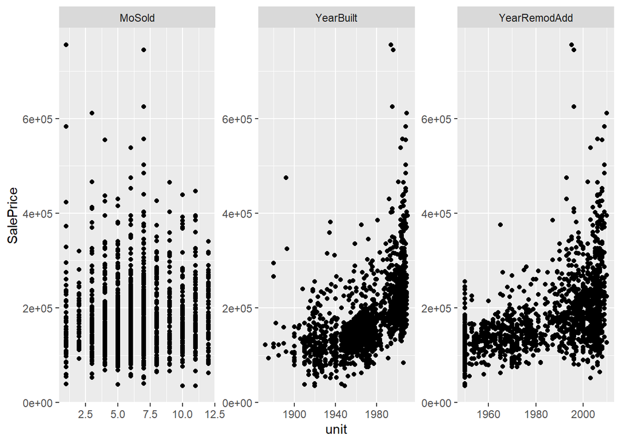

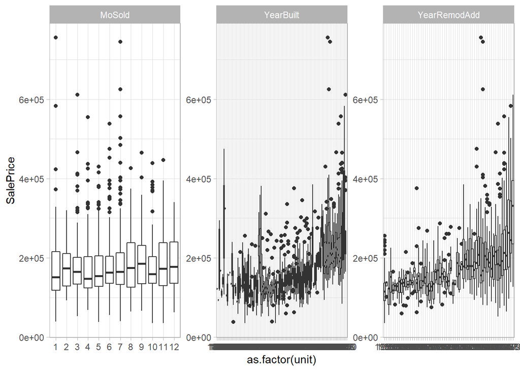

There is no particular effect of month sold on Sale price. However, In general we dprices does increase Year on Year which makes common sense.

# Data Cleaning Based on our EDA

The code below will fix few missing values which are actually features not present in a property. These features are related to . Alley . Bsmt . Garage . FireplaceQu . PoolQC . Fence . MiscFeatures . MasVnr

Last we remove Id, Sale Price and set variable that will not contribute to the model.

```r
#pp3
house <- train %>%

  #converting sales to log scale
  mutate(log_sale_price = log(SalePrice)) %>%


  #fill in missing values NA for factor variables as per data description

  #Alley
  mutate(Alley = if_else(is.na(Alley), "No Alley", Alley)) %>%

  #Bsmt
  mutate(
    BsmtCond = if_else(is.na(BsmtCond), "No Bsmnt", BsmtCond),
    BsmtExposure =  if_else(is.na(BsmtExposure), "No Bsmnt", BsmtExposure),
    BsmtQual = if_else(is.na(BsmtQual), "No Bsmnt", BsmtQual),
    BsmtFinType1 =  if_else(is.na(BsmtFinType1), "No Bsmnt", BsmtFinType1),
    BsmtFinType2 =  if_else(is.na(BsmtFinType2), "No Bsmnt", BsmtFinType2),
    BsmtFinSF1 =  if_else(is.na(BsmtFinSF1), 0, BsmtFinSF1),
    BsmtFinSF2 =  if_else(is.na(BsmtFinSF2), 0, BsmtFinSF2),
    BsmtUnfSF =  if_else(is.na(BsmtUnfSF), 0, BsmtUnfSF),
    TotalBsmtSF =  if_else(is.na(TotalBsmtSF), 0, TotalBsmtSF),
    BsmtFullBath =  if_else(is.na(BsmtFullBath), 0, BsmtFullBath),
    BsmtHalfBath =  if_else(is.na(BsmtHalfBath), 0, BsmtHalfBath)

  ) %>%

  #Garage
  #GarageType, GarageType, GarageFinish, GarageQual, GarageCond, 'GarageYrBlt', 'GarageArea', 'GarageCars'
  mutate(
    GarageType = if_else(is.na(GarageType), "No Garage", GarageType),
    GarageFinish =  if_else(is.na(GarageFinish), "No Garage", GarageFinish),
    GarageQual = if_else(is.na(GarageQual), "No Garage", GarageQual),
    GarageCond =  if_else(is.na(GarageCond), "No Garage", GarageCond),
    GarageYrBlt =  if_else(is.na(GarageYrBlt), 0, GarageYrBlt),
    GarageArea =  if_else(is.na(GarageArea), 0, GarageArea),
    GarageCars =  if_else(is.na(GarageCond), 0, GarageCars)
  ) %>%

  mutate(MasVnrType = if_else(is.na(MasVnrType), "No MasVnrType", MasVnrType)) %>%
  mutate(MasVnrArea = if_else(is.na(MasVnrArea), 0, MasVnrArea)) %>%


  #FireplaceQu, PoolQC,Fence, MiscFeature
  mutate(
    FireplaceQu = if_else(is.na(FireplaceQu), "No Fireplc", FireplaceQu),
    PoolQC =  if_else(is.na(PoolQC), "No Pool", PoolQC),
    Fence = if_else(is.na(Fence), "No Fence", Fence),
    MiscFeature =  if_else(is.na(MiscFeature), "None", MiscFeature)
  ) %>%

  mutate(YrBuilt_cat = cut2(YearBuilt, cuts = seq(min(YearBuilt), max(YearBuilt), 5))) %>%

  mutate(YearRemodAdd = if_else(is.na(YearRemodAdd), YearBuilt, YearRemodAdd)) %>%


  #remove non contributing features and IDs
  select(-Id,-SalePrice, -set)
```

# Creating a Training and Validation(test) set using rsample

```r
set.seed(1234)
house_split <- initial_split(house)

train_split <- training(house_split)
```

# Create recepies with series of preprocessing steps on training set

```r
house_recipe <- train_split %>%
  recipe(log_sale_price ~ .) %>%
  step_string2factor(all_nominal(), -all_outcomes()) %>%
  step_num2factor(MoSold, levels = as.character(unique(train_split$MoSold))) %>%
  step_num2factor(YrSold, levels = as.character(unique(train_split$YrSold))) %>%
  step_num2factor(MSSubClass, levels = as.character(unique(train_split$MSSubClass))) %>%
  step_num2factor(OverallCond, levels = as.character(unique(train_split$OverallCond))) %>%
  step_dummy(all_nominal(), -all_outcomes()) %>%
  step_center(all_predictors(), -all_outcomes()) %>%
  step_scale(all_predictors(), -all_outcomes()) %>%
  step_corr(all_predictors()) %>%
  step_nzv(all_predictors()) %>%
  step_knnimpute(all_predictors(), -all_outcomes())


doParallel::registerDoParallel()
house_prep <- prep(house_recipe)


house_recipe_treebased <- train_split %>%
  recipe(log_sale_price ~ .) %>%
  step_string2factor(all_nominal(), -all_outcomes()) %>%
  step_num2factor(MoSold, levels = as.character(unique(train_split$MoSold))) %>%
  step_num2factor(YrSold, levels = as.character(unique(train_split$YrSold))) %>%
  step_num2factor(OverallCond, levels = as.character(unique(train_split$OverallCond))) %>%
  step_num2factor(MSSubClass, levels = as.character(unique(train_split$MSSubClass))) %>%
  step_dummy(all_nominal(), -all_outcomes()) %>%
  step_corr(all_numeric()) %>%
  step_nzv(all_numeric()) %>%
  step_knnimpute(all_predictors(), -all_outcomes())

doParallel::registerDoParallel()
house_treebased_prep <- prep(house_recipe_treebased)
```

# Applying preprocessing on training and validation(testing) set

```r
house_train <- juice(house_prep)
house_test <- bake(house_prep, testing(house_split))

#splits for tree based models
house_train_treebased <- juice(house_treebased_prep)
house_test_treebased <- bake(house_treebased_prep, testing(house_split))
```

## Train models

### Train linear regression

```r
#linear model
lm_model <- #recipe(log_sale_price ~ . , data = house_train) %>%
  linear_reg() %>%
  set_mode("regression") %>%
  set_engine("lm") %>%
  fit(log_sale_price ~ . , data = house_train)
```

Important variables from linear model

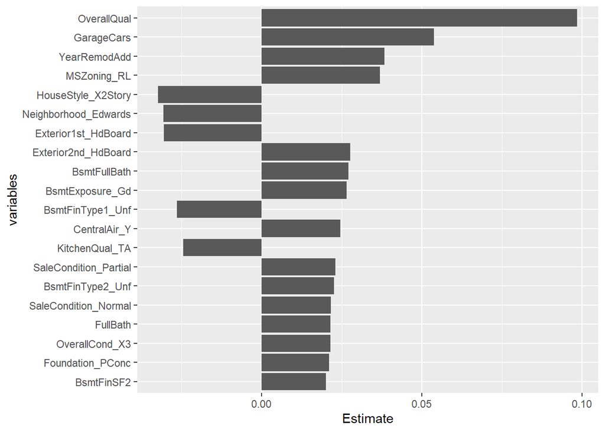

### Train random forest

```r
#create recepie on the preped house train data
rf_rec <-
  recipe(log_sale_price ~. , data = house_train_treebased)

#give model spec
rf_mod <-
  rand_forest(mtry = tune(), min_n = tune()) %>%
  set_engine("ranger") %>%
  set_mode("regression")

#create Search grid
rf_grid <-
  grid_regular(mtry(range = c(15,40)), min_n(range= c(10, 2)), levels = 5)

#create samples for cross validation
folds <- vfold_cv(house_train_treebased, v = 10)


doParallel::registerDoParallel()

#create models with grid search
rf_res <-
  tune_grid(model = rf_mod, rf_rec,resamples = folds ,  grid = rf_grid)

final_mtry <- select_best(rf_res, "rmse", maximize = FALSE)$mtry
final_min_node <- select_best(rf_res, "rmse", maximize = FALSE)$min_n

#random forest
rf_model <- rand_forest(mtry = final_mtry, min_n = final_min_node) %>%
  set_mode("regression") %>%
  set_engine("ranger",importance = 'impurity') %>%
  fit(log_sale_price ~ . , data = house_train_treebased)
```

Important variables from randome forest model

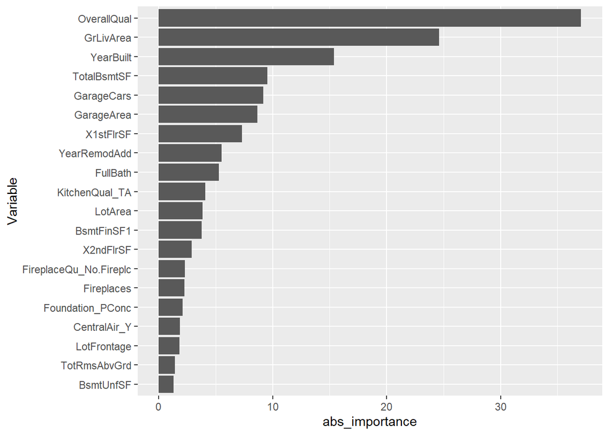

### train xgboost

```r
doParallel::registerDoParallel()
#xgboost
xg_model <- boost_tree() %>%
  set_mode("regression") %>%
  set_engine("xgboost") %>%
  fit(log_sale_price ~ . , data = house_train_treebased)
```

Important variables from xgoost model

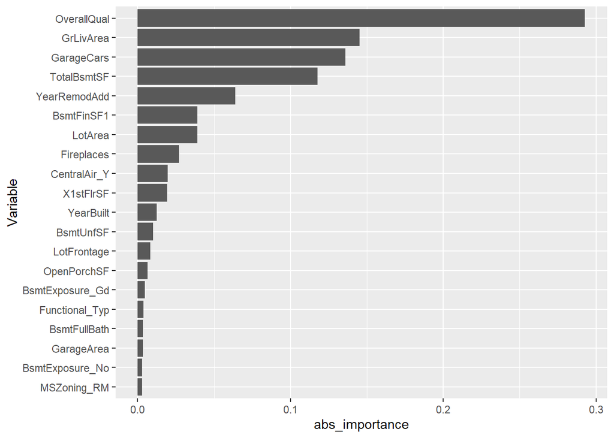

### train linear model ridge

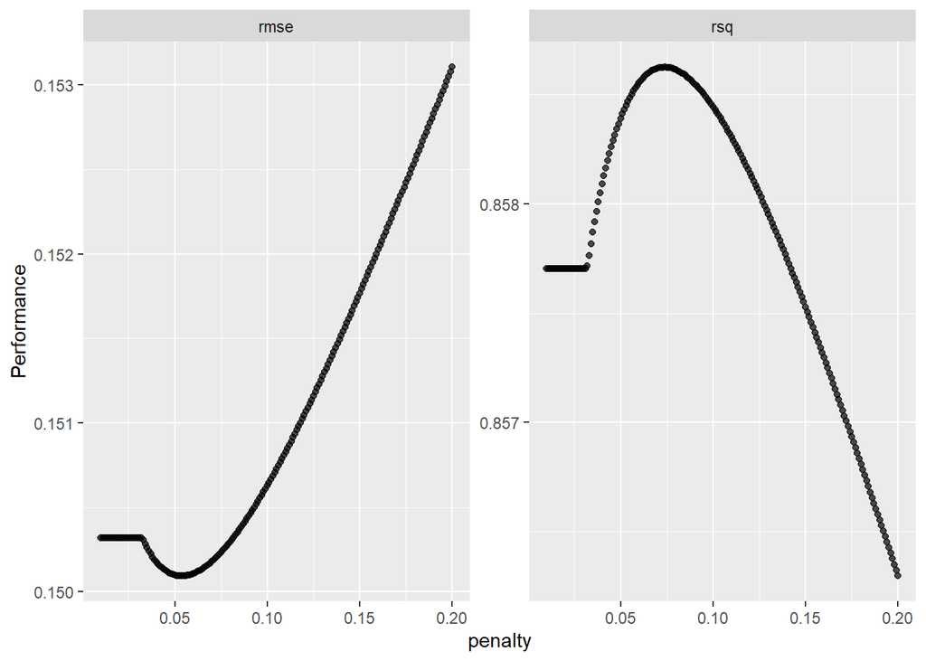

```r
ridge_rec <-
  recipe(log_sale_price ~. , data = house_train)

ridge_mod <-
  linear_reg(penalty = tune(), mixture = tune()) %>%
  set_engine("glmnet")


ridge_grid <- expand.grid(penalty = seq(from = 0.01, to = 0.2, by=0.001), mixture = 0)

folds <- vfold_cv(house_train, v = 10)

doParallel::registerDoParallel()

ridge_res <-
  tune_grid(ridge_rec, model = ridge_mod, resamples = folds ,  grid = ridge_grid)

autoplot(ridge_res)
```

```r
final_penalty <- select_best(ridge_res, "rmse", maximize = FALSE)$penalty

#apply best tuning parameter linear model ridge
lm_ridge_model <- linear_reg(penalty = final_penalty , mixture = 0) %>%
  set_mode("regression") %>%
  set_engine("glmnet") %>%
  fit(log_sale_price ~. , data = house_train)
```

Important variables from ridge model

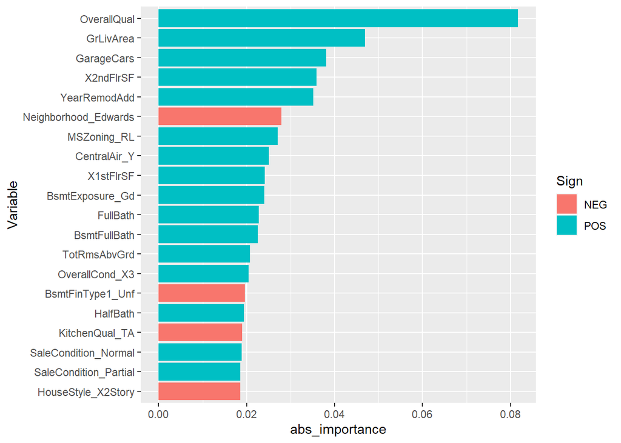

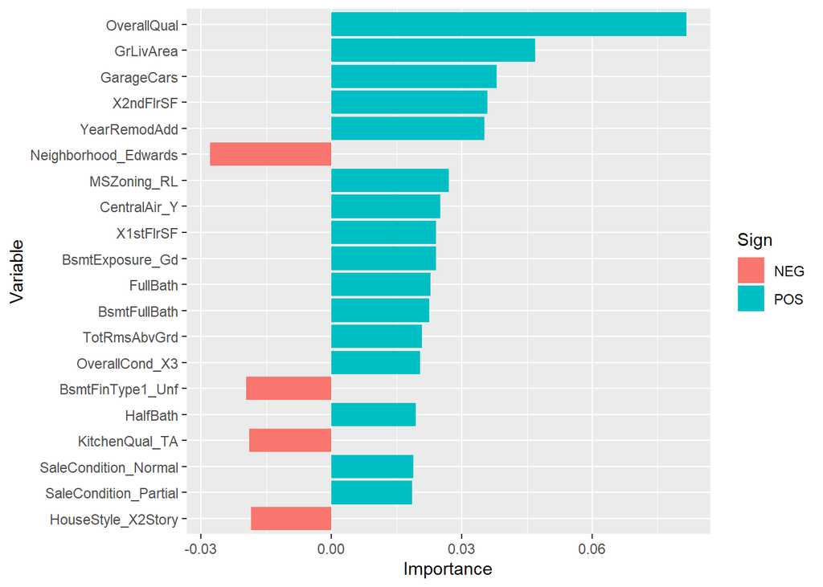

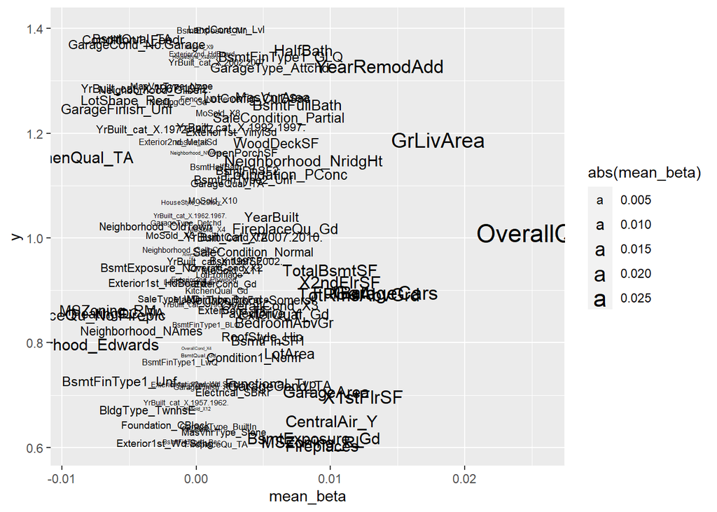

### linear model lasso

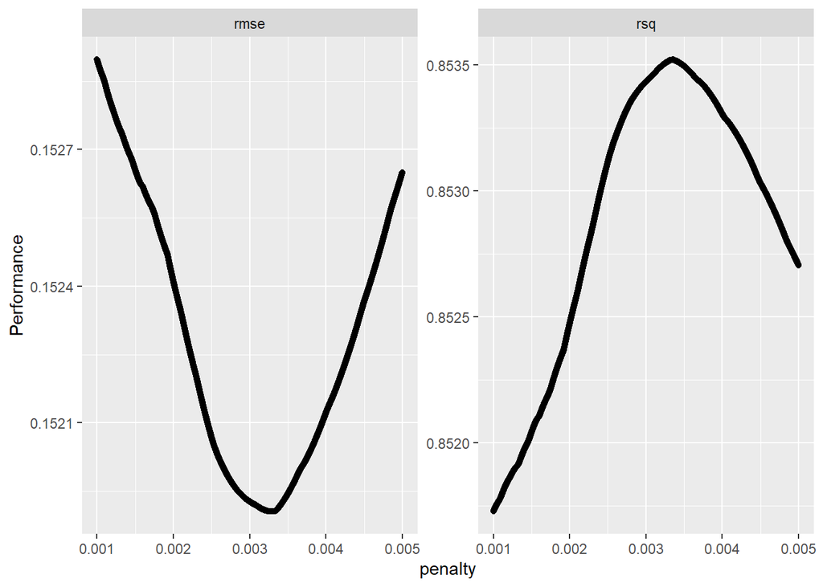

```r
lasso_rec <-
  recipe(log_sale_price ~. , data = house_train)

lasso_mod <-
  linear_reg(penalty = tune(), mixture = tune()) %>%
  set_engine("glmnet")

lasso_grid <- expand.grid(penalty = seq(from = 0.001, to = 0.005, by = 0.000001), mixture = 1)

folds_lasso <- vfold_cv(house_train, v = 10)

lasso_res <-
  tune_grid(lasso_rec, model = lasso_mod, resamples = folds_lasso ,  grid = lasso_grid)

lambda_final <-
  select_best(lasso_res, metric = "rmse", maximize = FALSE) %>% select(penalty) %>% unlist

autoplot(lasso_res)
```

```r
#apply best tuning parameter linear model ridge
lm_lasso_model <- linear_reg(penalty =  lambda_final, mixture = 1) %>%
  set_mode("regression") %>%
  set_engine("glmnet") %>%
  fit(log_sale_price ~. , data = house_train)
```

Important variables from lasso model

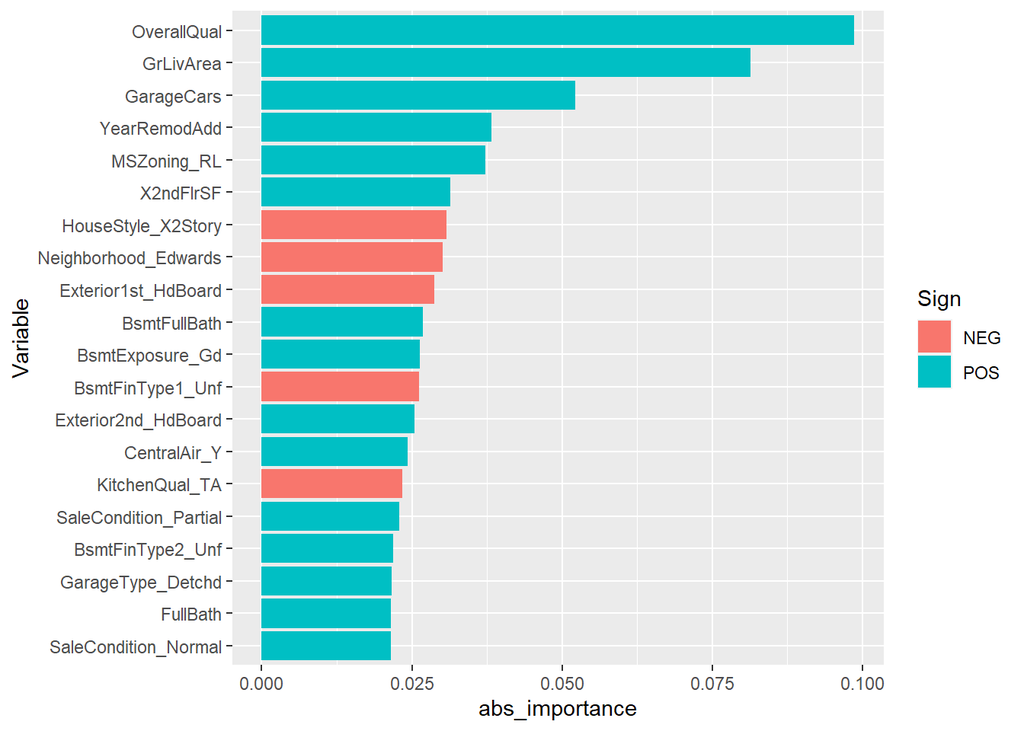

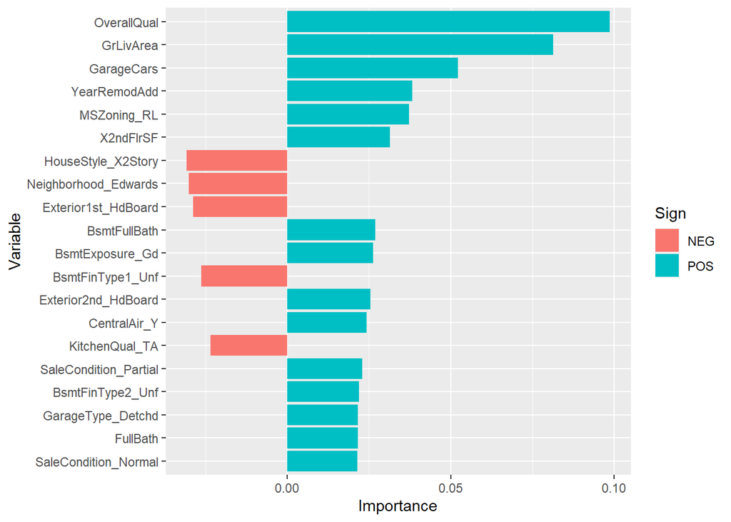

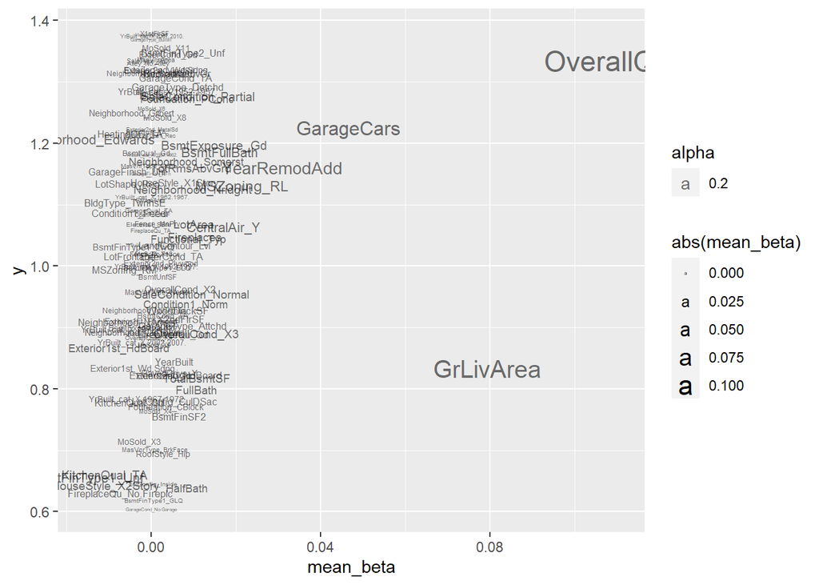

# Evaluate and consolidate model metrics

```
## # A tibble: 5 x 4
##   .metric m_type  train  test
##   <chr>   <chr>   <dbl> <dbl>
## 1 rmse    lm     0.129  0.142
## 2 rmse    rf     0.0534 0.142
## 3 rmse    xg     0.107  0.159
## 4 rmse    ridge  0.133  0.142
## 5 rmse    lasso  0.135  0.138
```

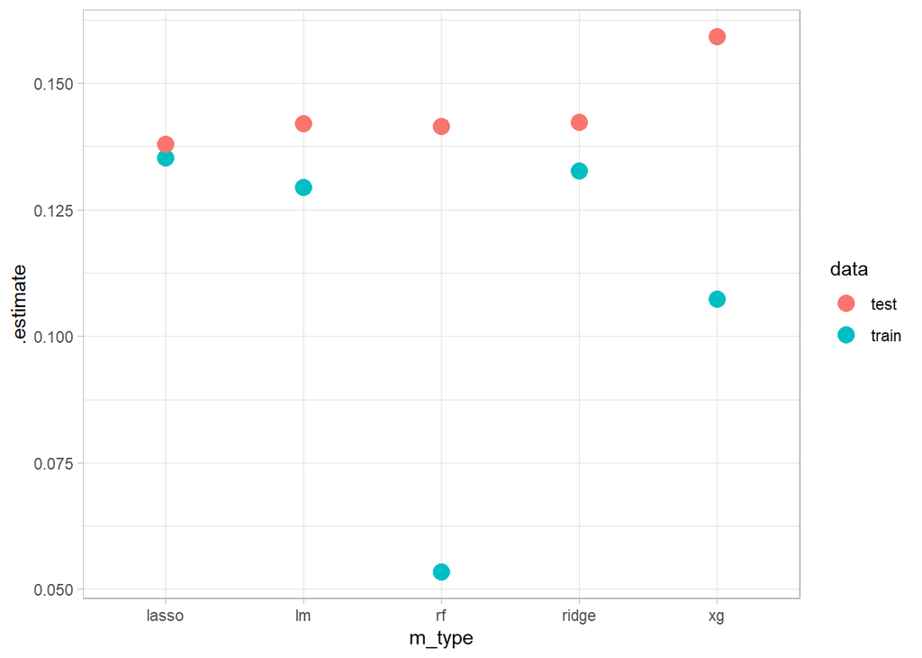

# Select Model

The lasso model gives the best test RMSE value.